# Ever wonder where the flights you hear are going?

Living in a city with an international airport, we often hear flights pass by overhead. Have you every wondered were those flights were going or coming back from? What airline it was? What type of plane? Well all of that information and more is all avaliable on flightradar24 which you can access as an app on webpage. Today we’re going to take a look at a breakdown of some of the data about the flights I have observed.

## What cities are most connected to Auckland Airport?

First of all destination and origin airports! Whether or not the flight is an arrival or a departure, the city it’s going to or coming from tells us a lot about how connected Auckland Airport is. I collected data over a period of 7 days. Here you can see the cities grouped by continent, due to New Zealand’s geographical position we are only connected to three continents via direct flights. Each bar of the chart is then broken down by city (it’s a lot I know!). At first glance we can see that Oceania and Asia cities are the most connected, with the most flights to Sydney. But have you every wondered about what type of planes are used for what destinations? Let’s take a look at that next!

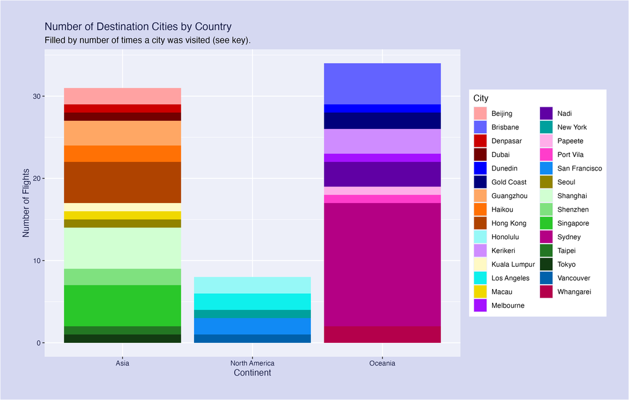

A bar graph grouped by continent and colour coded by cities of which cities flight from Auckland airport serve.

## What type of planes fly the longest?

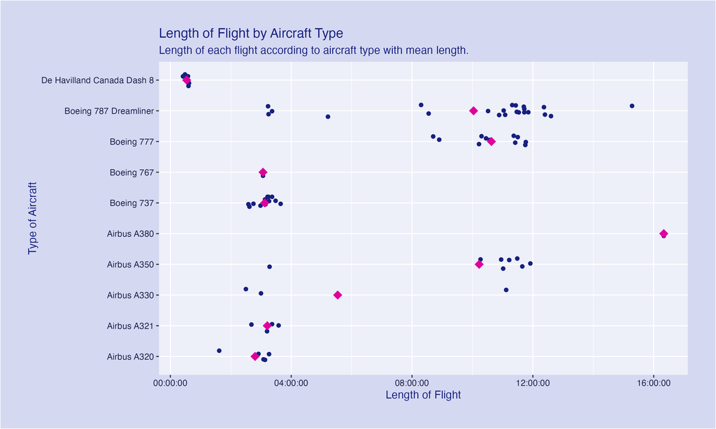

A scatter plot showing the flight times and average flight time of different aircraft types.

## What time were the most flights observed?

Now let’s take a look at what time flights left and the frequency of flights. We can see that almost all flights leave from the hours of 0800 to 0000, which makes sense as passenger flights would not leave at 3am! We can see that flights leave very frequently throughout the day to Australia which makes sense. And that there is a cluster of flights leaving at around 2200 to China which also makes sense as they fly over night and arrive early in the morning. Most of the flights to America also leave late at night, with the rest of the flights scattered throughout the day.

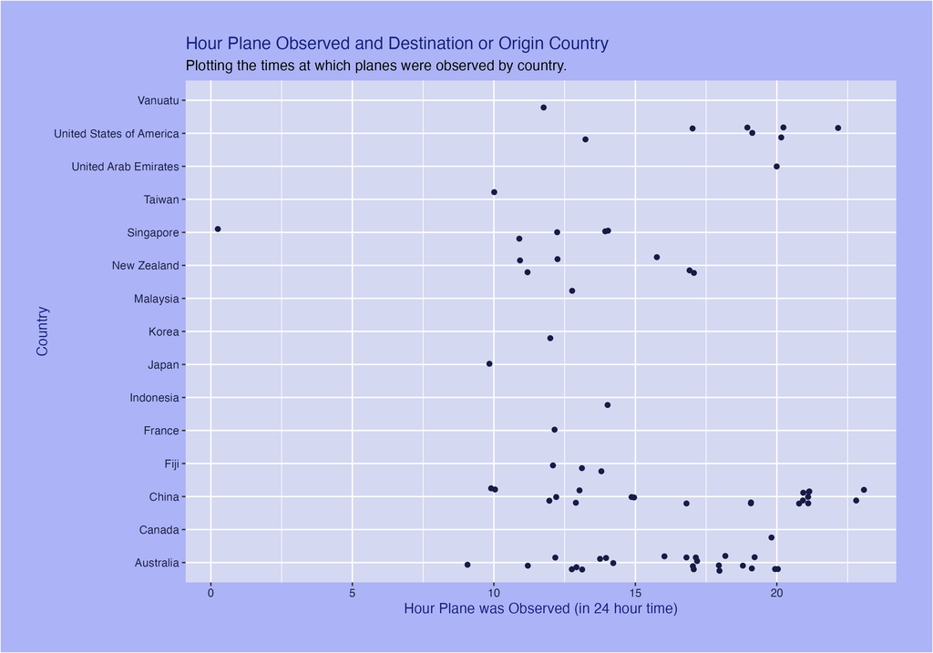

A scatter plot showing what time flights were observed.

## In conclusion!

This was a fun thing to collect and analyse data about! We can see that there are a high frequency of flights to Australia and China. And a really wide range of flights to 15 countries. Auckland is a very well connected international aiport. Given our distance to other countries there are a lot of very long flights too. I added a bar chart showing airline data too!

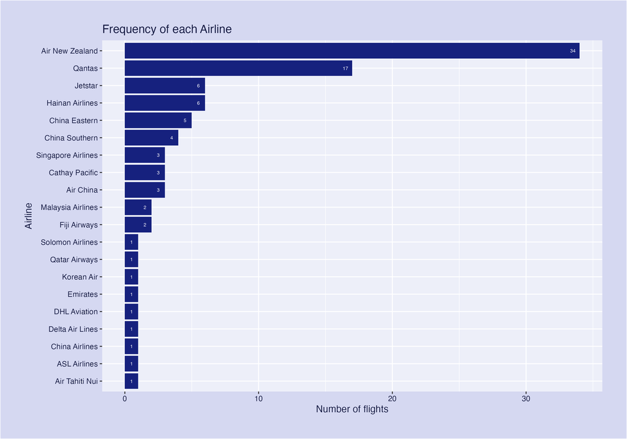